# Adult Data exploration with AWS EC2-HW4

Beichen Su

5/29/2017

# 1. Introduction

The data source is found on UCI Machine Learning data sets, called Adult: http://archive.ics.uci.edu/ml/machine-learning-databases/adult/

## 1.1 Summary and task

The data contains 48842 observations of 15 variable for each person in the survey. The task is using 14 of them as predictors and determining whether a person’s income is greater than 50k per year.

## Notice!

1 will represent >50K and 0 will represent <=50k in the further models, as the study focus on predicting people with income >50k per year and the roc curve stands for true positive rate and false positive rate.

## 1.2 Attributes

There is actually no conflict between those attributes, every kind of combination could exist so I don’t think it’s necessary to dive a lot in to those attributes.

For detailed information of each predictor, you can refer following:

age: continuous.

workclass: Private, Self-emp-not-inc, Self-emp-inc, Federal-gov, Local-gov, State-gov, Without-pay, Never-worked.

fnlwgt: continuous.

education: Bachelors, Some-college, 11th, HS-grad, Prof-school, Assoc-acdm, Assoc-voc, 9th, 7th-8th, 12th, Masters, 1st-4th, 10th, Doctorate, 5th-6th, Preschool.

education-num: continuous.

marital-status: Married-civ-spouse, Divorced, Never-married, Separated, Widowed, Married-spouse-absent, Married-AF-spouse.

occupation: Tech-support, Craft-repair, Other-service, Sales, Exec-managerial, Prof-specialty, Handlers-cleaners, Machine-op-inspct, Adm-clerical, Farming-fishing, Transport-moving, Priv-house-serv, Protective-serv, Armed-Forces.

relationship: Wife, Own-child, Husband, Not-in-family, Other-relative, Unmarried.

race: White, Asian-Pac-Islander, Amer-Indian-Eskimo, Other, Black.

sex: Female, Male.

capital-gain: continuous.

capital-loss: continuous.

hours-per-week: continuous.

native-country: United-States, Cambodia, England, Puerto-Rico, Canada, Germany, Outlying-US(Guam-USVI-etc), India, Japan, Greece, South, China, Cuba, Iran, Honduras, Philippines, Italy, Poland, Jamaica, Vietnam, Mexico, Portugal, Ireland, France, Dominican-Republic, Laos, Ecuador, Taiwan, Haiti, Columbia, Hungary, Guatemala, Nicaragua, Scotland, Thailand, Yugoslavia, El-Salvador, Trinadad&Tobago, Peru, Hong, Holand-Netherlands.

## 1.3 Data input and preparation

The initial data consists of two parts, one trainning and one test data set. For data clean and set up purpose, I prefer to combine the data first.

Check if there’s any NA in the data

```
##            age      workclass         fnlwgt      education  education_num
##              0              0              0              0              0
## marital_status     occupation   relationship           race            sex
##              0              0              0              0              0
##   capital_gain   capital_loss hours_per_week native_country         income
##              0              0              0              0              0
```

The result shows that there is no NA in the data, which suggests there is no missing value or the missing value is represented in a different way for character input. It’s important to check unique values in each string attributes.

```r
unique(originalData$workclass)
```

```
## [1] "State-gov"        "Self-emp-not-inc" "Private"
## [4] "Federal-gov"      "Local-gov"        "?"
## [7] "Self-emp-inc"     "Without-pay"      "Never-worked"
```

```r
unique(originalData$education)
```

```
##  [1] "Bachelors"    "HS-grad"      "11th"         "Masters"
##  [5] "9th"          "Some-college" "Assoc-acdm"   "Assoc-voc"
##  [9] "7th-8th"      "Doctorate"    "Prof-school"  "5th-6th"
## [13] "10th"         "1st-4th"      "Preschool"    "12th"
```

```r
unique(originalData$marital_status)
```

```
## [1] "Never-married"         "Married-civ-spouse"    "Divorced"
## [4] "Married-spouse-absent" "Separated"             "Married-AF-spouse"
## [7] "Widowed"
```

```r
unique(originalData$occupation)
```

```
##  [1] "Adm-clerical"      "Exec-managerial"   "Handlers-cleaners"
##  [4] "Prof-specialty"    "Other-service"     "Sales"
##  [7] "Craft-repair"      "Transport-moving"  "Farming-fishing"
## [10] "Machine-op-inspct" "Tech-support"      "?"
## [13] "Protective-serv"   "Armed-Forces"      "Priv-house-serv"
```

```r
unique(originalData$relationship)
```

```
## [1] "Not-in-family"  "Husband"        "Wife"           "Own-child"
## [5] "Unmarried"      "Other-relative"
```

```r
unique(originalData$race)
```

```
## [1] "White"              "Black"              "Asian-Pac-Islander"
## [4] "Amer-Indian-Eskimo" "Other"
```

```r
unique(originalData$sex)
```

```
## [1] "Male"   "Female"
```

```r
unique(originalData$native_country)
```

```
##  [1] "United-States"              "Cuba"
##  [3] "Jamaica"                    "India"
##  [5] "?"                          "Mexico"
##  [7] "South"                      "Puerto-Rico"
##  [9] "Honduras"                   "England"
## [11] "Canada"                     "Germany"
## [13] "Iran"                       "Philippines"
## [15] "Italy"                      "Poland"
## [17] "Columbia"                   "Cambodia"
## [19] "Thailand"                   "Ecuador"
## [21] "Laos"                       "Taiwan"
## [23] "Haiti"                      "Portugal"
## [25] "Dominican-Republic"         "El-Salvador"
## [27] "France"                     "Guatemala"
## [29] "China"                      "Japan"
## [31] "Yugoslavia"                 "Peru"
## [33] "Outlying-US(Guam-USVI-etc)" "Scotland"
## [35] "Trinadad&Tobago"            "Greece"
## [37] "Nicaragua"                  "Vietnam"
## [39] "Hong"                       "Ireland"
## [41] "Hungary"                    "Holand-Netherlands"
```

```r
unique(originalData$income)
```

```
## [1] "<=50K"  ">50K"   "<=50K." ">50K."
```

The pattern shows that the missing values in the character attributes are represented by “?” and there are two version of the income representation, with “.” or without “.”.

### 1.3.1 Delete the row with missing value

The missing value brings in confusion to further analysis, as we might have no idea about what “?” representing, I prefer to delete all rows with “?” from the data set, if this operation will not delete the whole data set luckily.

```r
originalData = originalData[-which(originalData$workclass == "?"),]
originalData = originalData[-which(originalData$occupation == "?"),]
originalData = originalData[-which(originalData$native_country == "?"),]
dim(originalData)
```

```
## [1] 45222    15
```

Now there are 45222 observation remaining, which indicates that we lost 3620 observation but the outcome is not too bad, that only 7.4% rows contain missing value.

### 1.3.2 Regulation of the income representation

In this section I convert both “<=50k” and “<=50k.” to “<=50k”,

and “>50k” and “>50k.” to “>50k” for regulation.

```r
dim(originalData)
```

```
## [1] 45222    15
```

For those 45222 observation, the data contains 34014 observation marked as the income is less than or equal to 50k per year and 11208 for greater than 50k per year.

Then making the string predictors as factors

## 1.4 Graphical presentation of the data

Severl plot of predictors and income will be presented below in order to discover the trend and what makes a difference for annul income greater than 50k.

### 1.4.1 Age

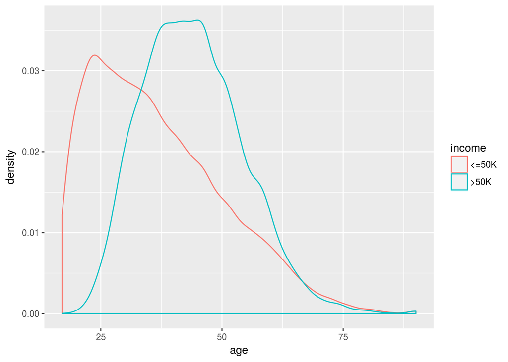

It’s obvious to see that as the age increases, people are more likely to have higher income.

### 1.4.2 Final weight

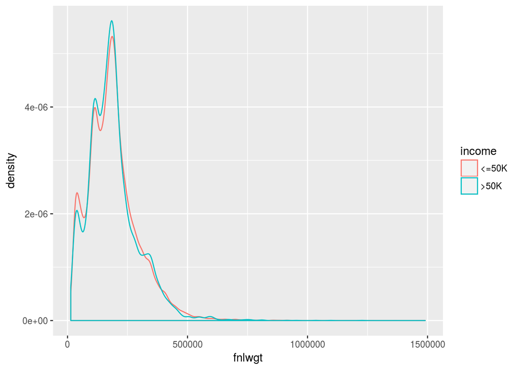

This final weight attributes doesn’t seem to play an important role for the binary classification.

### 1.4.3 Education Number

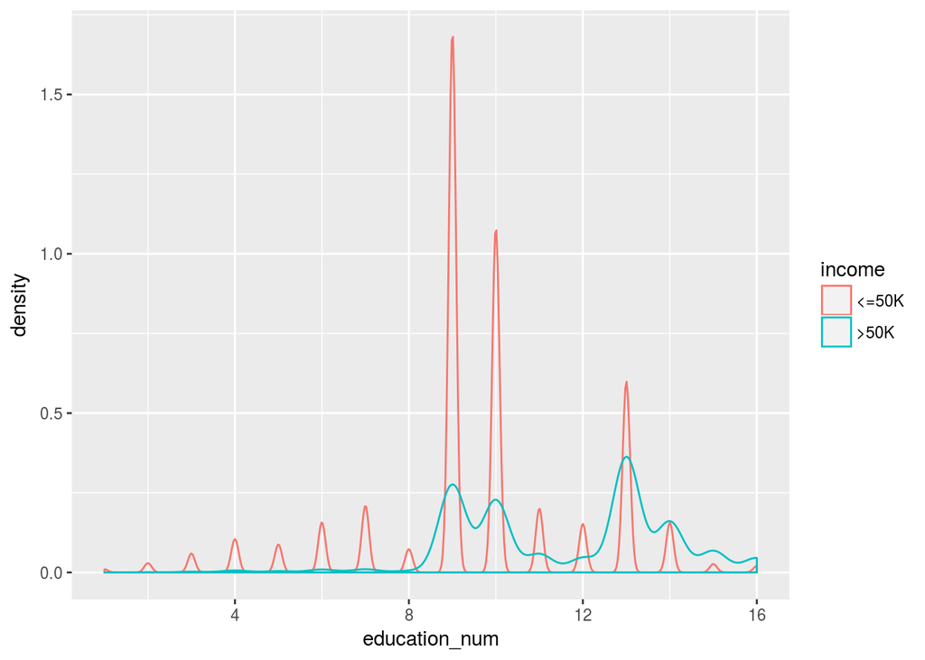

This graph brings in a lot of information.

As for those make more than 50k per year, almost everyone has at least 8 years of education history, and more than have of them have more than 12 years of education.

For those make equal or less than 50k per year, most of them have 9 or 10 years of education background. What this graph suggests is that, receiving longer education might let you make more money, but the difference is not distinct.

It’s might be interesting to check their education degree for the next part, degree and education number are closely connected.

### 1.4.4 Education Degree

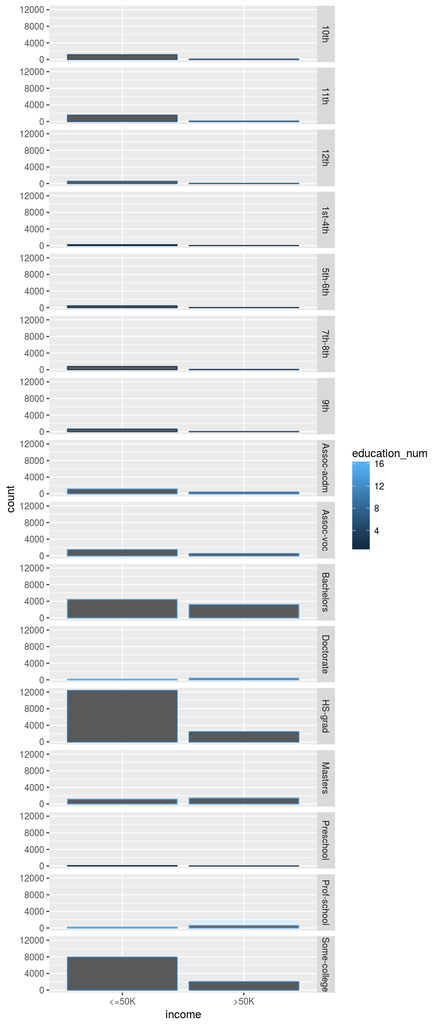

As there are more people have less or equal to 50k per year, it’s not surperising that for most kinds of degree, the number with <=50k is greater than >50k. But it’s necessary to notice that for prof-school, master, and doctorate, there are more >50k.

### 1.4.5 Marital status

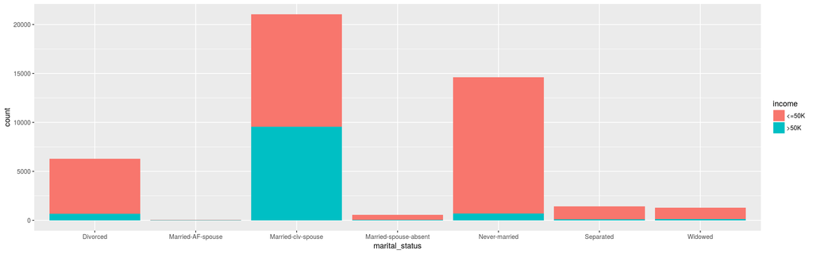

Still, as there are more people with <=50k income, the status “married-civ-spouse” might bring in more income as the graph suggests.

### 1.4.6 Occupation

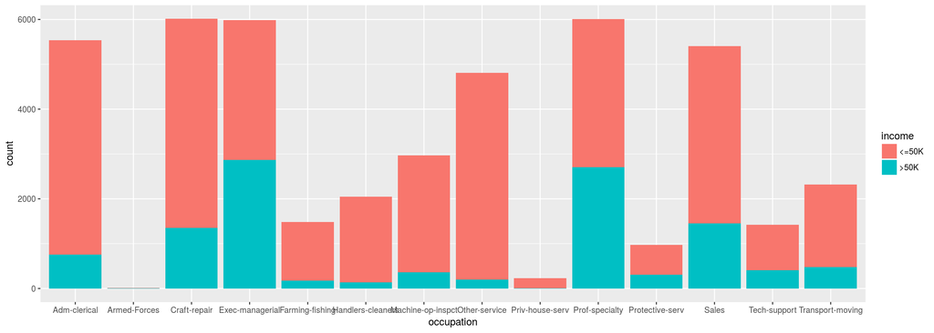

The graph suggests that exec-managerial and prof-specialty brings in more income.

### 1.4.7 Work class

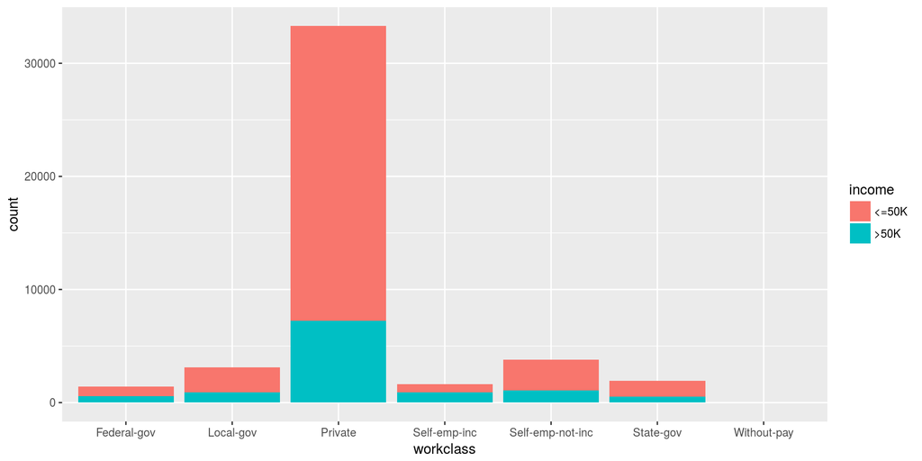

### 1.4.8 Race and Sex

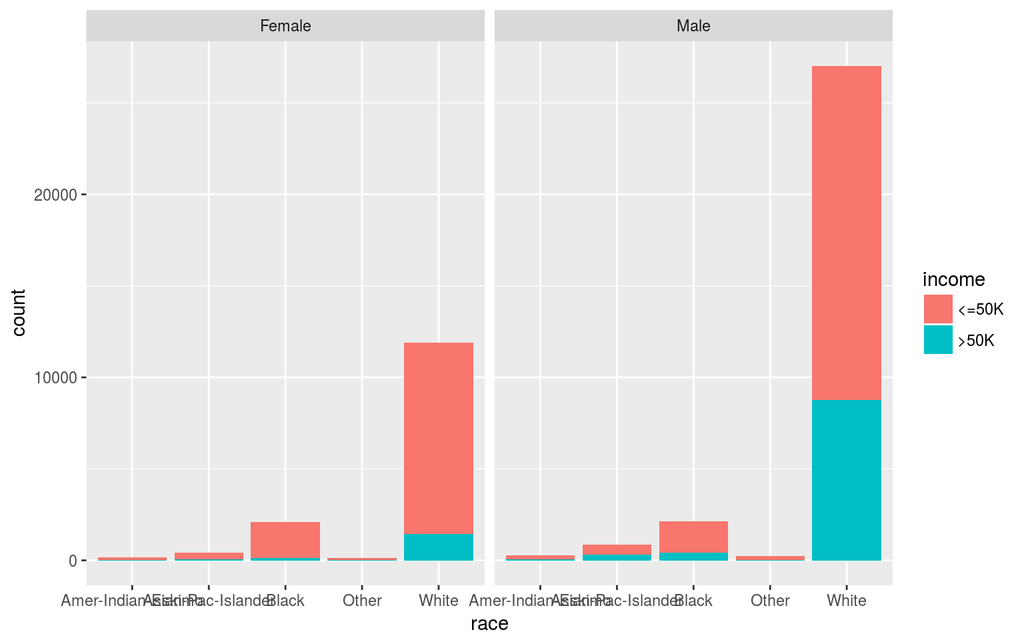

For both male and female, it looks like that white people have the greater probalibity to have more than 50k income. And male have the greater probalibity to have more than 50k income generally.

### 1.4.9 Capital gain and loss

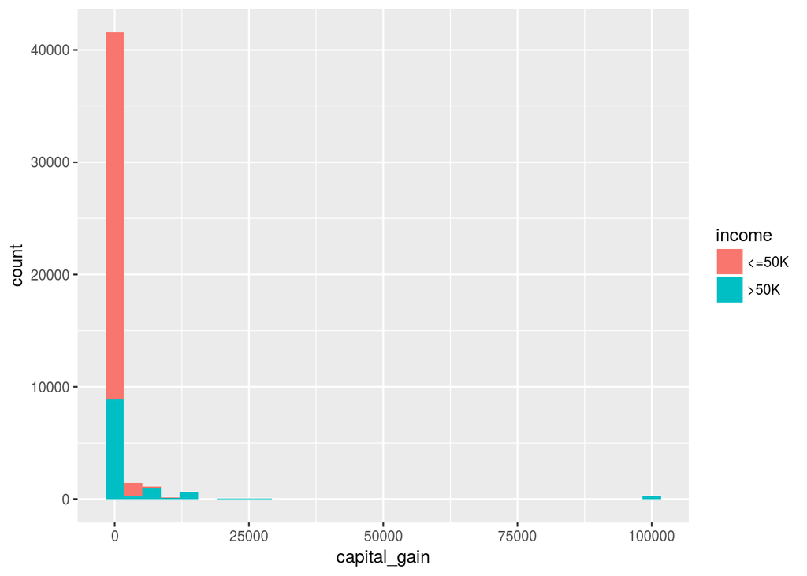

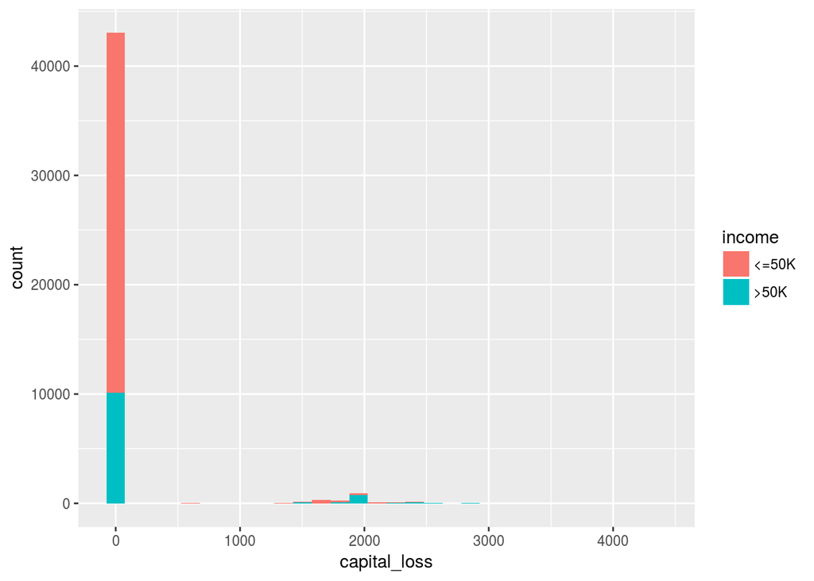

For both gain and loss, most of them have score 0, but people with income greater than 50k per year, the scores are higher in both cases.

### 1.4.10 Native country

```
##              United-States                Philippines
##               23.103799036                0.185750299
##                      India                     Canada
##                0.137101411                0.132678785
##                    Germany                    England
##                0.128256159                0.103931715
##                     Mexico                      China
##                0.103931715                0.079607271
##                       Cuba                      Italy
##                0.075184645                0.072973332
##                      Japan                     Taiwan
##                0.068550705                0.055282827
##                       Iran                Puerto-Rico
##                0.048648888                0.044226262
##                     Greece                      South
##                0.039803635                0.039803635
##                     France                     Poland
##                0.035381009                0.035381009
##                    Jamaica                   Portugal
##                0.030958383                0.026535757
##                El-Salvador                    Ireland
##                0.024324444                0.022113131
##                   Cambodia                      Haiti
##                0.019901818                0.019901818
##                       Hong                 Yugoslavia
##                0.017690505                0.017690505
##                    Vietnam                    Ecuador
##                0.015479192                0.013267878
##                    Hungary         Dominican-Republic
##                0.013267878                0.011056565
##                   Thailand                   Columbia
##                0.011056565                0.008845252
##                       Peru                  Guatemala
##                0.008845252                0.006633939
##                  Nicaragua                   Honduras
##                0.006633939                0.004422626
##                       Laos                   Scotland
##                0.004422626                0.004422626
##            Trinadad&Tobago Outlying-US(Guam-USVI-etc)
##                0.004422626                0.002211313
##         Holand-Netherlands
##                0.000000000
```

# 2. Statistical model and analysis

In this section, seveal machine learning models would be employed, in order to do comparison and better prediction. And models in the last course work will be reviewed, as a summary to the whole project.

The analysis will mainly based on H2O, and auc will be used as the mectric of goodness. ROC curve and analysis will be provided for each model.

For regulation, I set “>50k” as 1 and “<=50k” as 0 for income, as the study is focus on predict people with >50k income and the roc curve stands for true positive rate and false positive rate.

The whole script is running on an Amazon EC2 t2.2xlarge instance on Ubantu system with 8 core and 32 GB memory.

For the validation purpose, the whole data would be divided into training, validation and test set(60%, 20%, 20%) at random. As H2O provided build in function for validation, the validation set is omitted.

## 2.1 Logistic Regression (Review)

Here’s the summary of the logistic regression model with best lambda.

The training auc is

```
## [1] 0.9053479
```

The validation auc is

```
## [1] 0.9056933
```

And the best lambda is given as:

```
## [1] 0.0001790699
```

The prediction auc on test set and roc curve is given below.

```
## [1] 0.9034104
```

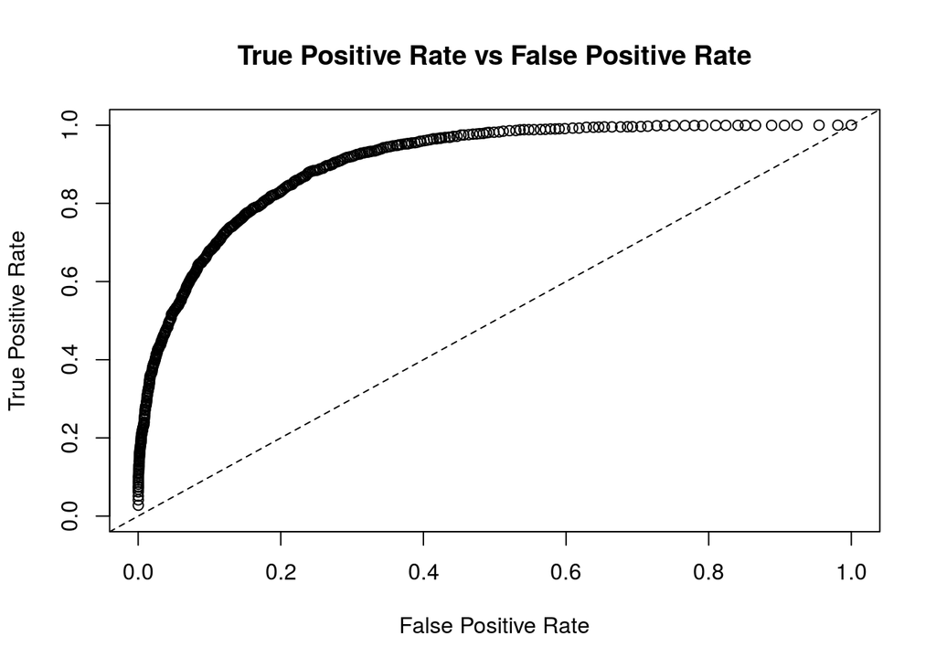

The tuning on lambda suggests we should pick a value close to 0, and the auc given by training, validation and test set are all above 0.9, which shows that the overtraining is avoided and the model fits pretty good.

The roc curve provides a insight of trade off between TPR and FPR based on the cutoff point.

As the focus is on predicting people with >50k income, it’s reasonable to choose max f2 as a criterion, which stands for 1 in this case. The confusion matrix of training data is given.

```
## Confusion Matrix (vertical: actual; across: predicted)  for max f2 @ threshold = 0.146435709814754:
##            0     1    Error         Rate
## 0      14110  6338 0.309957  =6338/20448
## 1        468  6287 0.069282    =468/6755
## Totals 14578 12625 0.250193  =6806/27203
```

For training data, to obtain the best TPR and FPR, the cutoff point is given by 0.14645.

The confusion matrix of validation data:

```
## Confusion Matrix (vertical: actual; across: predicted)  for max f2 @ threshold = 0.184288516379946:
##           0    1    Error        Rate
## 0      4992 1784 0.263282  =1784/6776
## 1       207 1977 0.094780   =207/2184
## Totals 5199 3761 0.222210  =1991/8960
```

For validation data, to obtain the best TPR and FPR, the cutoff point is given by 0.18429.

Choosing cutoff point at 0.18429 yields 9.5% error on predicting people with >50k income for the validation data. And for the test data

```
## Confusion Matrix (vertical: actual; across: predicted)  for max f2 @ threshold = 0.16341824368971:
##           0    1    Error        Rate
## 0      4801 1989 0.292931  =1989/6790
## 1       187 2082 0.082415   =187/2269
## Totals 4988 4071 0.240203  =2176/9059
```

So that the threshold can be picked for different data based on the model, in order to gain better prediction for >50k or <=50k.

This result is reliable and more trade off can be found on H2O flow.

## 2.2 Random forest (Review)

The random forest algorithm is employed with H2O implementation. The validation set is used with early stopping technique, with stopping round at 4, stopping tolerance at 0.01 and stopping metric of AUC.

The random forest model gives training auc at:

```
## [1] 0.8836636
```

And validation auc at:

```
## [1] 0.9052833
```

And test auc at:

```
## [1] 0.9056511
```

The optimal tree number to avoid overtraining is:

```
## [1] 11
```

And the auc for training and validation sets as the number of trees grows is given by:

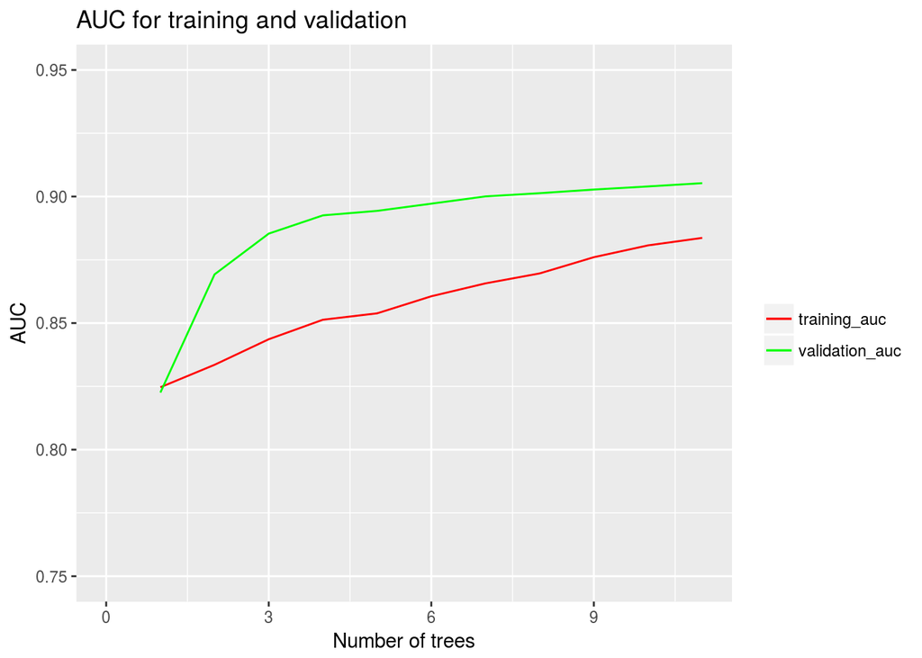

The AUC stopped to increase as the number of trees equal to 11, so that the model stopped here to avoid overtraining.

With the roc curve on test set:

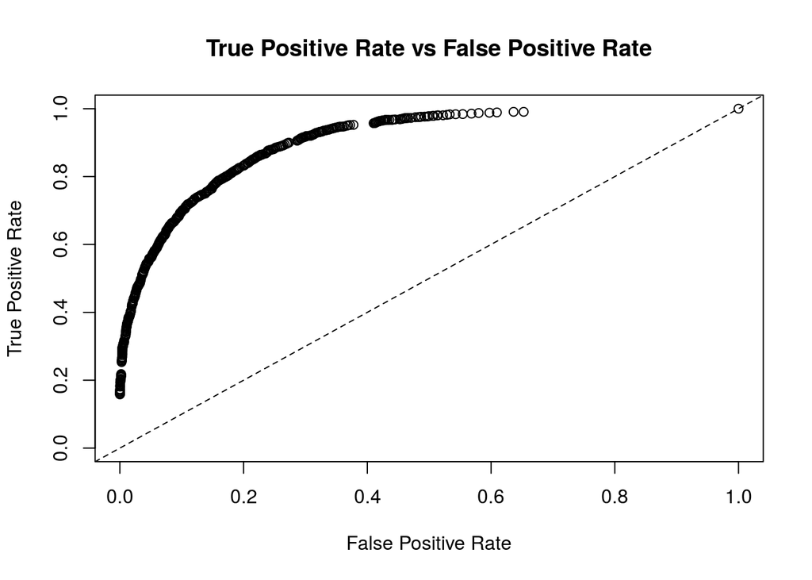

```r
plot(h2o.performance(model_RF,dx_test))
```

Generally speaking, the auc for training, validation and test sets are all around 0.9, and this metric is a little bit lower for the training set based on the seed I set for reproducibility.

Below I produced the best cut off point for TPR and FPR, along with the confusion matrix at the cutoff point.

For training set

```
## Confusion Matrix (vertical: actual; across: predicted)  for max f2 @ threshold = 0.11101813154029:
##            0     1    Error         Rate
## 0      13728  6613 0.325107  =6613/20341
## 1        554  6150 0.082637    =554/6704
## Totals 14282 12763 0.265003  =7167/27045
```

The optimal cut off point to gain best TPR and FPR as a trade off is given by 0.111. And this yields TPR at

```
## [1] 0.917363
```

and FPR at

```
## [1] 0.325107
```

This cut off points is pretty low, producing a nice true positive rate, which means for those people really have >50k income, the model predicts with 0.917363 accuracy.

But for those people actually have <=50k income, as the model trends to emphasize the prediction power on >50k income so that the cut off point is pretty small and close to 0, the model assigns 32.5% of <=50 to >50 by mistake.

For the validation set:

```
## Confusion Matrix (vertical: actual; across: predicted)  for max f2 @ threshold = 0.208122584584988:
##           0    1    Error        Rate
## 0      5122 1654 0.244097  =1654/6776
## 1       242 1942 0.110806   =242/2184
## Totals 5364 3596 0.211607  =1896/8960
```

The optimal cut off point for the validation data is at 0.20812.

And for the test data, the confusion matrix is given by:

```
## Confusion Matrix (vertical: actual; across: predicted)  for max f2 @ threshold = 0.138208803669973:
##           0    1    Error        Rate
## 0      4633 2157 0.317673  =2157/6790
## 1       161 2108 0.070956   =161/2269
## Totals 4794 4265 0.255878  =2318/9059
```

And it reports that picking a cut off point at 0.1382 would be optimal to predict people with >50k income, for which 1 stands. As the confusion matrix can tell, for those people really have >50k income, the model gives a prediction at 92.9% accuracy, which is pretty nice result and a little bit better compared to logistic regression.

## 2.3 Gradient boosting machine(Review)

For the GBM section, H2O is employed with early stopping technique for time saving and avoiding over-tranining.

Several model with different learning ratio is introduced with different learning ratio.

Those models begin with 600 tree which is way more than enough, stopping rounds = 3, stopping tolerance = 0.01, and max depth = 100 which gives enough room for tree to grow.

### No.1 GBM model, with learning ratio 0.01

The AUC change with the number of tree for training and validation set is given by

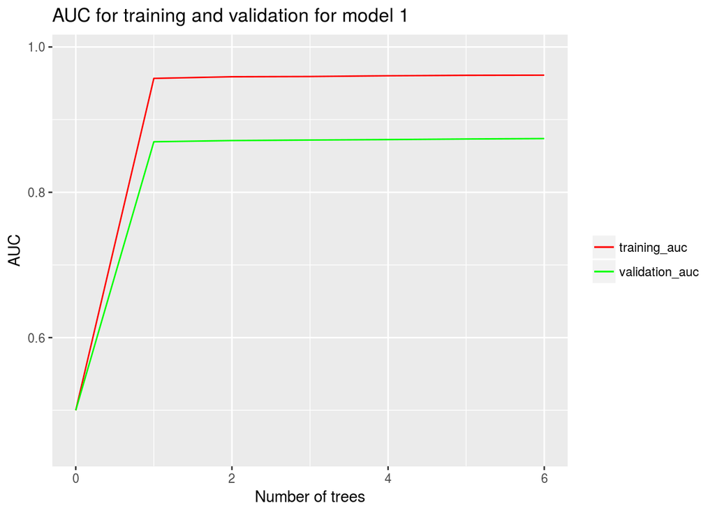

And he optimal number of trees to avoid overtraining with early stopping is given by

```
## [1] 6
```

And the mean depth of the trees in the model is :

```
## [1] 33.16667
```

The training auc:

```
## [1] 0.9611733
```

The confusion matrix for training set at maximum accuracy predicting people with >50k income

```
## Confusion Matrix (vertical: actual; across: predicted)  for max f2 @ threshold = 0.243705328446961:
##            0     1    Error         Rate
## 0      16126  4322 0.211365  =4322/20448
## 1        213  6542 0.031532    =213/6755
## Totals 16339 10864 0.166710  =4535/27203
```

This threshold gives TPR at 1-0.031532 = 0.968468 and FPR at 0.211365

The validation auc:

```
## [1] 0.8739188
```

The confusion matrix for validation set at maximum accuracy predicting people with >50k income

```
## Confusion Matrix (vertical: actual; across: predicted)  for max f2 @ threshold = 0.239504295603053:
##           0    1    Error        Rate
## 0      4658 2118 0.312574  =2118/6776
## 1       237 1947 0.108516   =237/2184
## Totals 4895 4065 0.262835  =2355/8960
```

This threshold gives TPR at 1-0.108516 = 0.891484 and FPR at 0.312.

The training set fits better than validation set, with more auc which results in higher TPR and lower FPR with best threshold/cutoff we can choose.

Now apply the model to the test data set.

The auc of the first GBM model on test data:

```
## [1] 0.8733638
```

And the ROC curve:

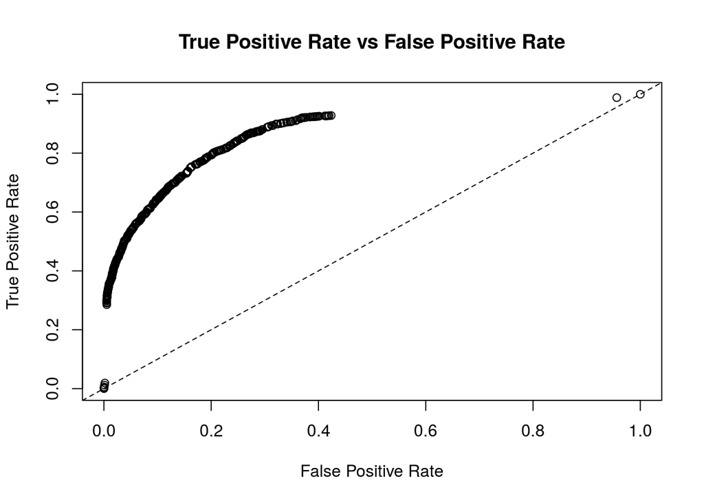

Now the confusion matrix with best f2 metric

```
## Confusion Matrix (vertical: actual; across: predicted)  for max f2 @ threshold = 0.238687280767902:
##           0    1    Error        Rate
## 0      4613 2177 0.320619  =2177/6790
## 1       230 2039 0.101366   =230/2269
## Totals 4843 4216 0.265703  =2407/9059
```

As observed a huge break on the roc curve, it suggests that there is a threshold after which almost every observation will be classified as >50k.

As the validation set and test set have less auc compared to the training data, I think there might still be overtraining in this model. But this can be a result of the learning ratio. So I adjust the learning ratio to 0.1 in the second GBM model.

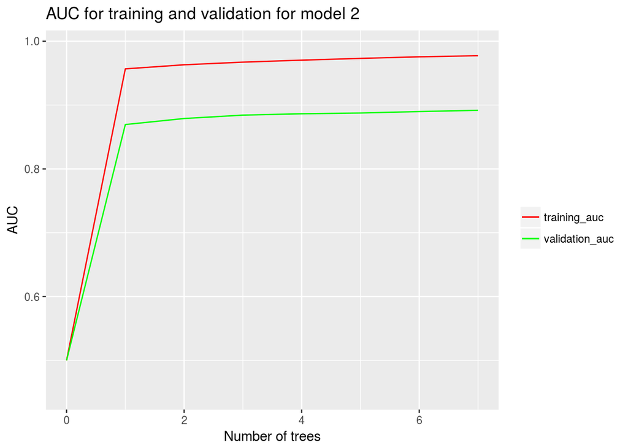

As the graph can tell, the training auc is much better than that of the validation set again.

With learning ratio 0.1, the optimal number of tree:

```
## [1] 7
```

And the mean depth of the trees

```r
model_GBM2@model$model_summary$mean_depth
```

```
## [1] 34.14286
```

The training auc

```
## [1] 0.9773643
```

The validation auc

```
## [1] 0.891858
```

The test auc

```
## [1] 0.8924523
```

And the ROC curve

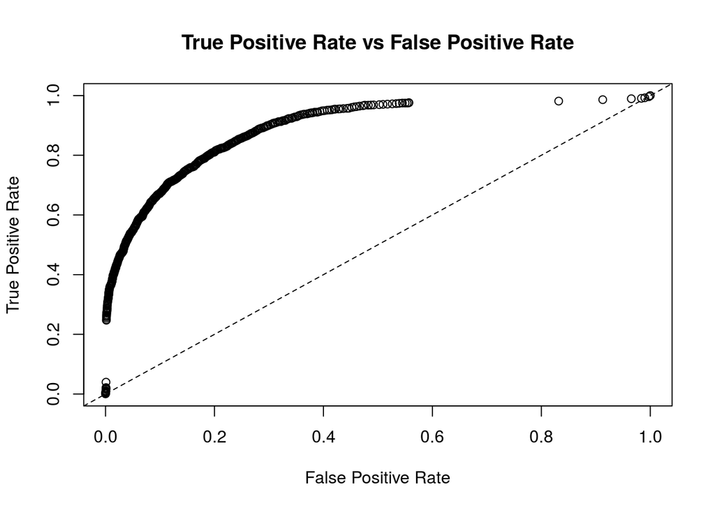

Increasing the learning ratio from 0.01 to 0.1 doesn’t really change the model a lot, we have one more tree few more mean depth and a little bit increased test auc. As the number and depth of trees can be picked by the model itself, it might be interesting to fit a series of GBM model with different learning ratio and compare the training and validation auc.

### Study on learning ratio with a series of GBM models

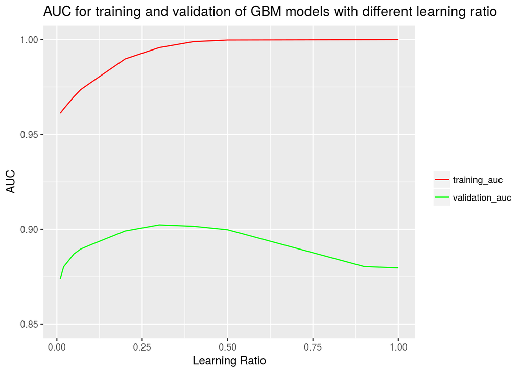

This graph gives a clear sense of what learning ratio did in the model, where I train the model with learning ratio of 0.01, 0.02, 0.05, 0.07, 0.1, 0.2, 0.3, 0.4, 0.5, 0.9, 1.Small and large value gives really poor, and increasing the learning ratio too much would result in overtraining. So for the best auc on validation set, the learning ratio is:

```
## [1] 0.3
```

GBM is extreme good at training, where it gives really high aucs for each model on training data but it’s poor on validation set.

### No.3 The revised GBM model with learning ratio at 0.3

This final model has learning ratio of 0.3, the number of trees is given by:

```
## [1] 8
```

The test auc:

```
## [1] 0.9028677
```

The ROC curve

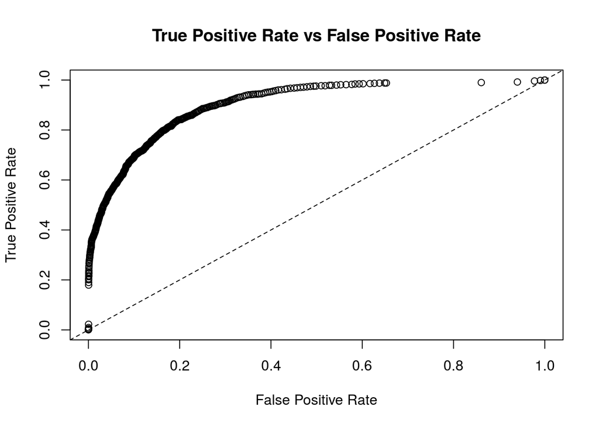

The confusion matrix for the test set

```
## Confusion Matrix (vertical: actual; across: predicted)  for max f2 @ threshold = 0.0817948245505278:
##           0    1    Error        Rate
## 0      4576 2214 0.326068  =2214/6790
## 1       161 2108 0.070956   =161/2269
## Totals 4737 4322 0.262170  =2375/9059
```

This final GBM model with learning ratio at 0.3 gives the highest test auc compared to the first two models.

As the best cut off point for predicting the people with >50k income, the threshold is given by 0.08179. This yields a TPR at 1-0.07096 = 0.929 and FPR at 0.326, which is not a too bad result.

### Hyperparameter optimization for GBMs with random search

In this section, the random search method will be employed in order to select the best hyperparameter, including max_depth, minimum number of rows, learning rate, learning rate annealing, sample rate of columns and number of bins.

Early stopping method is employed for each model with AUC as metric and tolerance at 1e-3.

The maximum number of models is 50 and the maximum run time is 3 mins.

It took a while for the model to run, and the run time is given as

```
##    user  system elapsed
##   1.876   0.040 181.719
```

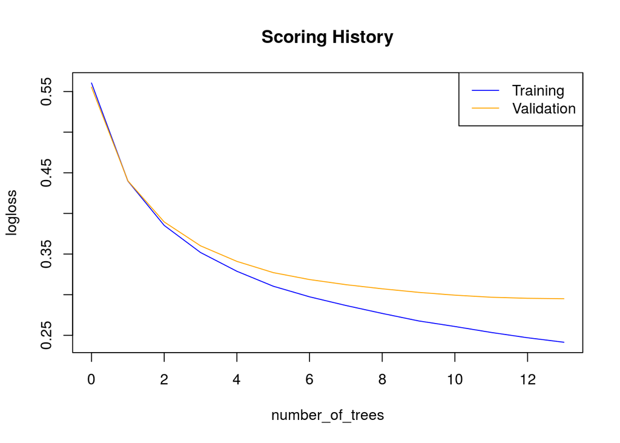

#### The model with the best auc for training and validation sets:

```
## Model Details:
## ==============
##
## H2OBinomialModel: gbm
## Model Key:  grd_model_8
## Model Summary:
##   number_of_trees number_of_internal_trees model_size_in_bytes min_depth
## 1              13                       13               47825        15
##   max_depth mean_depth min_leaves max_leaves mean_leaves
## 1        31   26.53846        165        211   199.07692
##
## H2OBinomialMetrics: gbm
## ** Reported on training data. **
##
## MSE:  0.07541044
## RMSE:  0.2746096
## LogLoss:  0.2414519
## Mean Per-Class Error:  0.130177
## AUC:  0.9537224
## Gini:  0.9074448
##
## Confusion Matrix (vertical: actual; across: predicted) for F1-optimal threshold:
##            0    1    Error         Rate
## 0      18445 2003 0.097956  =2003/20448
## 1       1097 5658 0.162398   =1097/6755
## Totals 19542 7661 0.113958  =3100/27203
##
## Maximum Metrics: Maximum metrics at their respective thresholds
##                         metric threshold    value idx
## 1                       max f1  0.361810 0.784961 212
## 2                       max f2  0.197301 0.851631 279
## 3                 max f0point5  0.613286 0.811604 125
## 4                 max accuracy  0.478215 0.891519 171
## 5                max precision  0.987317 1.000000   0
## 6                   max recall  0.025205 1.000000 373
## 7              max specificity  0.987317 1.000000   0
## 8             max absolute_mcc  0.361810 0.710452 212
## 9   max min_per_class_accuracy  0.307976 0.876684 233
## 10 max mean_per_class_accuracy  0.275892 0.877573 246
##
```

[output cut: 99 more lines]

```
##          variable relative_importance scaled_importance percentage
## 1    relationship         1913.259888          1.000000   0.336075
## 2       education          955.681702          0.499504   0.167871
## 3    capital_gain          928.671082          0.485387   0.163126
## 4      occupation          506.790497          0.264883   0.089021
## 5             age          330.698029          0.172845   0.058089
## 6    capital_loss          316.400391          0.165372   0.055577
## 7  hours_per_week          203.938416          0.106592   0.035823
## 8          fnlwgt          193.611511          0.101195   0.034009
## 9  marital_status          162.314865          0.084837   0.028511
## 10      workclass           98.017998          0.051231   0.017217
## 11 native_country           64.074013          0.033489   0.011255
## 12            sex           10.331580          0.005400   0.001815
## 13           race            8.199966          0.004286   0.001440
## 14  education_num            0.973606          0.000509   0.000171
```

#### The hyperparameter of this model is given by:

```
## $model_id
## [1] "grd_model_8"
##
## $training_frame
## [1] "RTMP_sid_9ba1_5"
##
## $validation_frame
## [1] "RTMP_sid_9ba1_9"
##
## $nfolds
## [1] 0
##
## $keep_cross_validation_predictions
## [1] FALSE
##
## $keep_cross_validation_fold_assignment
## [1] FALSE
##
## $score_each_iteration
## [1] FALSE
##
## $score_tree_interval
## [1] 0
##
## $fold_assignment
## [1] "AUTO"
##
## $ignore_const_cols
## [1] TRUE
##
## $balance_classes
## [1] FALSE
##
## $max_after_balance_size
## [1] 5
##
## $max_confusion_matrix_size
## [1] 20
##
## $max_hit_ratio_k
```

[output cut: 79 more lines]

```
##
## $pred_noise_bandwidth
## [1] 0
##
## $categorical_encoding
## [1] "AUTO"
##
## $x
##  [1] "age"            "workclass"      "fnlwgt"         "education"
##  [5] "education_num"  "marital_status" "occupation"     "relationship"
##  [9] "race"           "sex"            "capital_gain"   "capital_loss"
## [13] "hours_per_week" "native_country"
##
## $y
## [1] "income"
```

With the random-searched hyperparameter, let’s check out the performance of this model on the test set. The ROC curve and auc on the test data is given by:

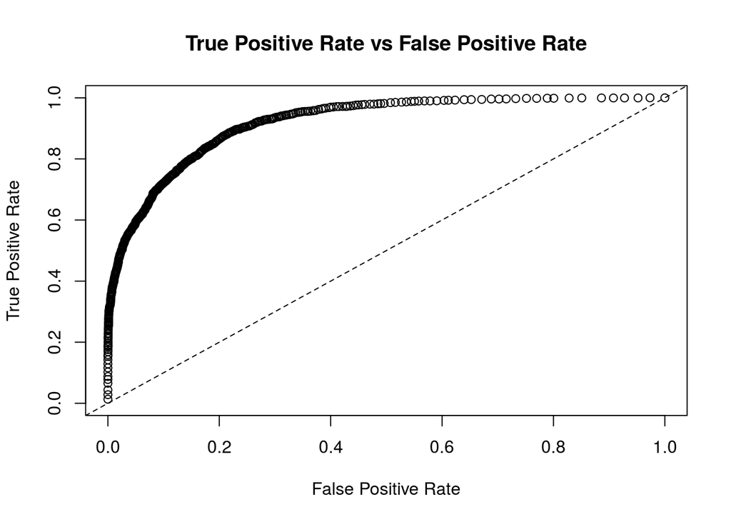

```
## [1] 0.9181308
```

## 2.4 Neural networks

In this section, several Neural network models with different parameters will be built. The validation set will be employed is order to apply early stopping technique.

For there would be a lot of model, for each neural network model I will only display the ROC curve, auc, best cut off point for predicting people with >50k income(f2 measure) and the run time.

For reproducibility, the seed is set at 123.

### No.1 NN model

The parameters are layer = c(200,200), activation function = “Rectifier”, epochs = 100, rate = 0.01, rate_annealing = 1e-05, momentum_start = 0.5, momentum_ramp = 1e4, momentum_stable = 0.9.

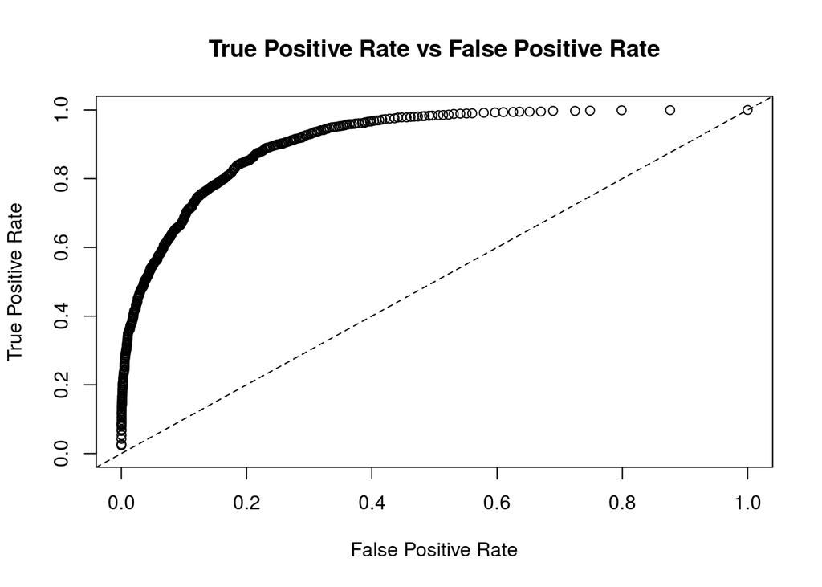

```
## Confusion Matrix (vertical: actual; across: predicted)  for max f2 @ threshold = 0.0930630150869568:
##           0    1    Error        Rate
## 0      4690 2100 0.309278  =2100/6790
## 1       145 2124 0.063905   =145/2269
## Totals 4835 4224 0.247820  =2245/9059
```

The test auc:

```
## [1] 0.9106385
```

The run time:

```
## elapsed
##  39.746
```

### No.2 NN model (changing into 3 layer, each with 50 neurons, keeping other constant)

The parameters are layer = c(50,50,50), activation function = “Rectifier”, epochs = 100, rate = 0.01, rate_annealing = 1e-05, momentum_start = 0.5, momentum_ramp = 1e4, momentum_stable = 0.9.

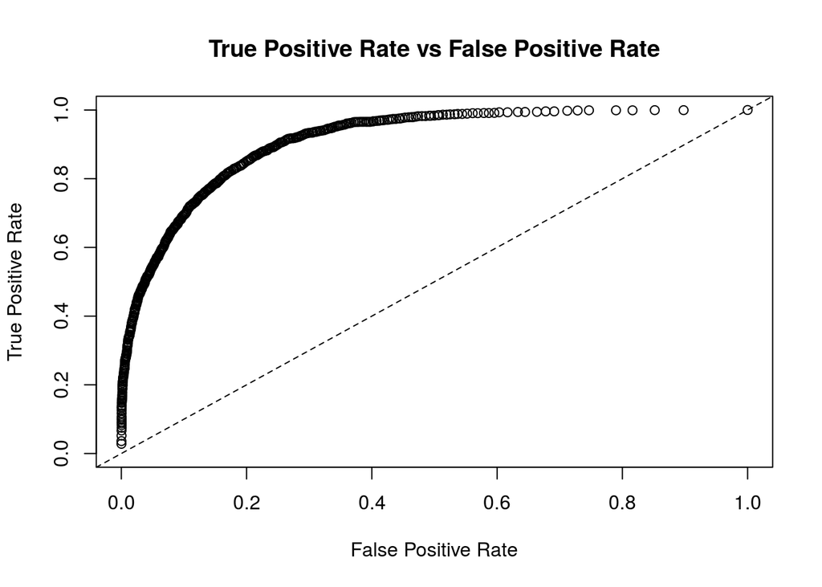

```
## Confusion Matrix (vertical: actual; across: predicted)  for max f2 @ threshold = 0.194302177697608:
##           0    1    Error        Rate
## 0      4978 1812 0.266863  =1812/6790
## 1       190 2079 0.083737   =190/2269
## Totals 5168 3891 0.220996  =2002/9059
```

The test auc:

```
## [1] 0.9109862
```

The run time:

```
## elapsed
##  11.524
```

### No.3 NN model (Same as No.2 except changing layer to 3 layers with 200 neurons each)

The parameters are layer = c(200,200,200), activation function = “Rectifier”, epochs = 100, rate = 0.01, rate_annealing = 1e-05, momentum_start = 0.5, momentum_ramp = 1e4, momentum_stable = 0.9.

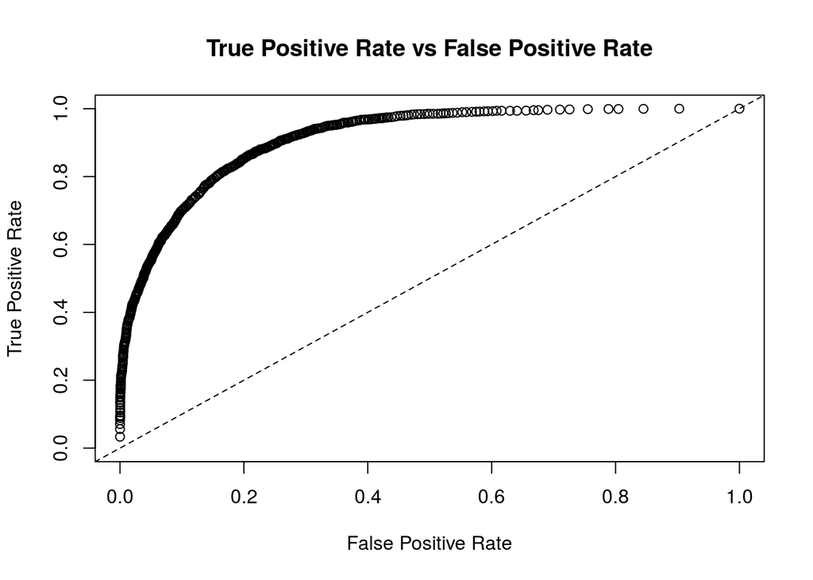

```
## Confusion Matrix (vertical: actual; across: predicted)  for max f2 @ threshold = 0.167704435819827:
##           0    1    Error        Rate
## 0      4661 2129 0.313549  =2129/6790
## 1       135 2134 0.059498   =135/2269
## Totals 4796 4263 0.249917  =2264/9059
```

The test auc:

```
## [1] 0.9120752
```

The run time:

```
## elapsed
##  90.218
```

This model is better than the first one with higher auc. More layers may result in a better model.

### No.4 NN model (Same as No.1 except changing activation function to “Tanh”)

The parameters are layer = c(200,200), activation function = “Tanh”, epochs = 100, rate = 0.01, rate_annealing = 1e-05, momentum_start = 0.5, momentum_ramp = 1e4, momentum_stable = 0.9.

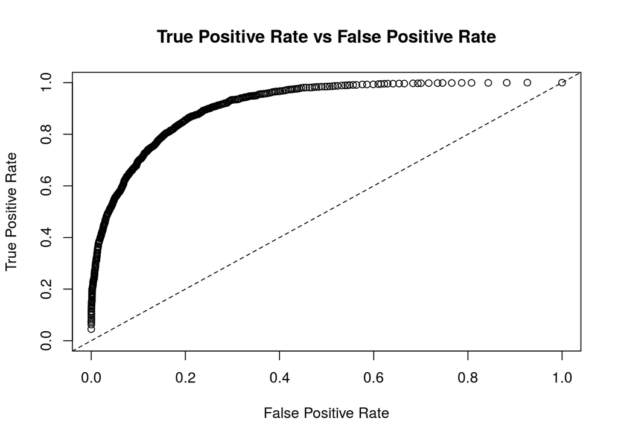

```
## Confusion Matrix (vertical: actual; across: predicted)  for max f2 @ threshold = 0.152656462327902:
##           0    1    Error        Rate
## 0      4773 2017 0.297054  =2017/6790
## 1       153 2116 0.067431   =153/2269
## Totals 4926 4133 0.239541  =2170/9059
```

The test auc:

```
## [1] 0.9111159
```

The run time:

```
## elapsed
##  114.52
```

### No.5 NN model (Same as No.1 except changing adaptive learning rate to TRUE, which makes momentum not applicable)

The parameters are layer = c(200,200), activation function = “Rectifier”, epochs = 100.

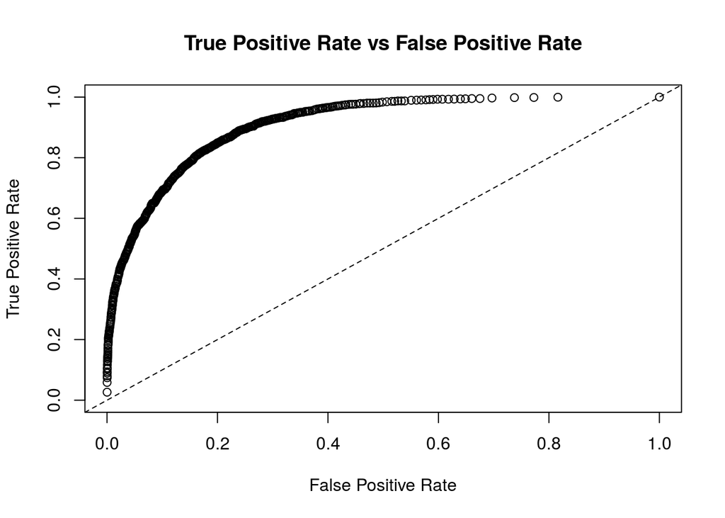

```
## Confusion Matrix (vertical: actual; across: predicted)  for max f2 @ threshold = 0.199979509998:
##           0    1    Error        Rate
## 0      4890 1900 0.279823  =1900/6790
## 1       185 2084 0.081534   =185/2269
## Totals 5075 3984 0.230158  =2085/9059
```

The test auc:

```
## [1] 0.9095248
```

The run time:

```
## elapsed
##  67.122
```

### No.6 NN model (4 layer 50 neurons each, regulization, drop out ratio)

Turns out that No.2 NN model performed well, so for this model I used the settings as used in No.2 NN model, with adaptive rate = TRUE, and one more layer: 4 hidden layers with 50 neurons each.

Add input dropout ratio = 0.2, and l1, l2 regulization as l1 = 2e-5, l2 = 2e-5.

Add hidden dropout ratios = c(0.2,0.2,0.2,0.2)

Since the deep learning is like the black magic, I add a lot of stuff in.

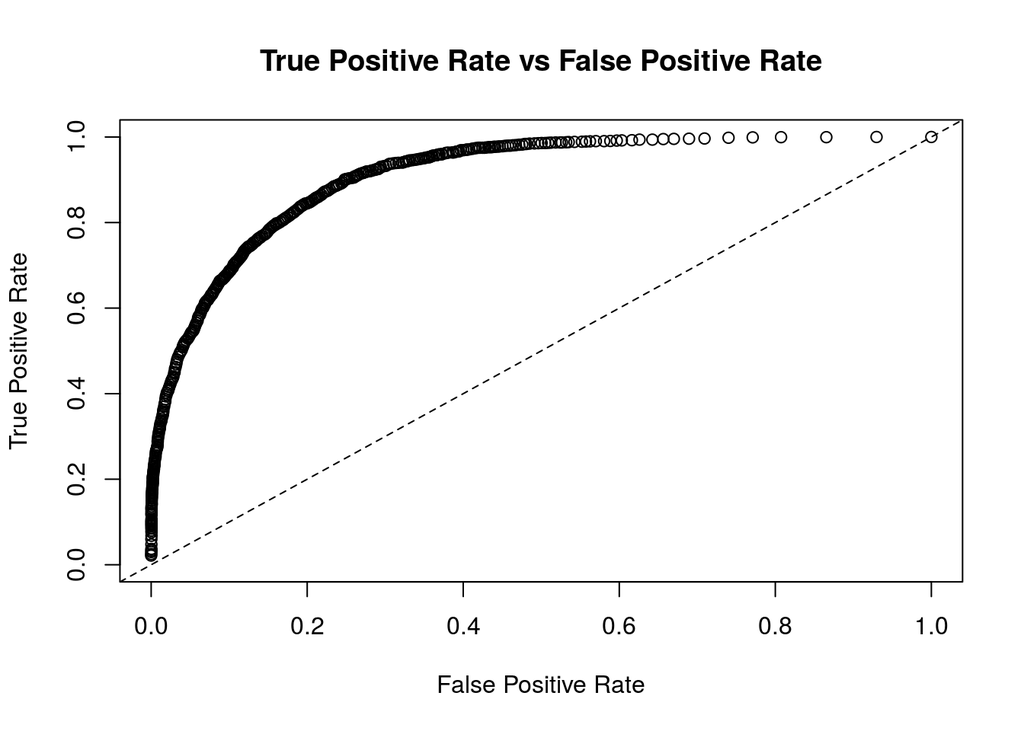

```
## Confusion Matrix (vertical: actual; across: predicted)  for max f2 @ threshold = 0.181911256585288:
##           0    1    Error        Rate
## 0      4720 2070 0.304860  =2070/6790
## 1       144 2125 0.063464   =144/2269
## Totals 4864 4195 0.244398  =2214/9059
```

The test auc:

```
## [1] 0.9095028
```

The run time:

[output not shown]

### Discussion on the neural network models

A graphic presentation of those neural network models, AUC vs Time(in seconds):

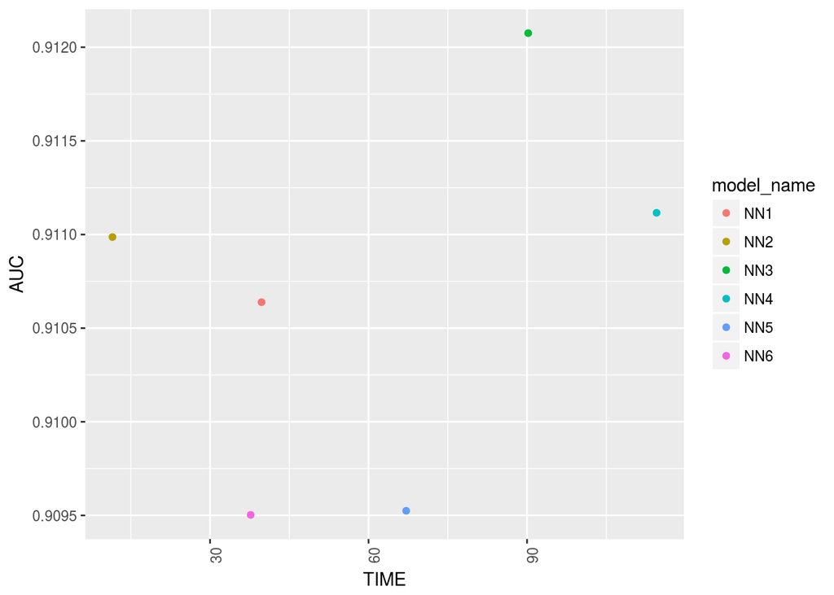

It’s interesting to observe that the AUCs for the test data on all neural network models are bigger than 0.9, which is an indictor for a good model.

It turns out that tanh is not a good activation for this data comparing to Rectifer, as it took the longest time but the AUC is not very high considering the time it took.

No.2 model turns out to have less time and considerablely high auc, while the auc didn’t change a lot among those cases. So I assume No.2 is the best Neural network model among those six.

## 2.5 Ensembling various models

In this section various models will be combined. I will choose the logistic regression model, the random forest, the best GBM model, and No.2 Neural Network model, which means that I will keep the parameter for those models.

As the stackedEnsembel function in h2o requires cross validation rather than a validation frame, a training set with 75% data and a test set with 25% data will be created.

4 models with different algorithm will be created with cross-validation within training data and the nfolds for each data is 5.

The ROC curve for the new model on 25% test data is given by:

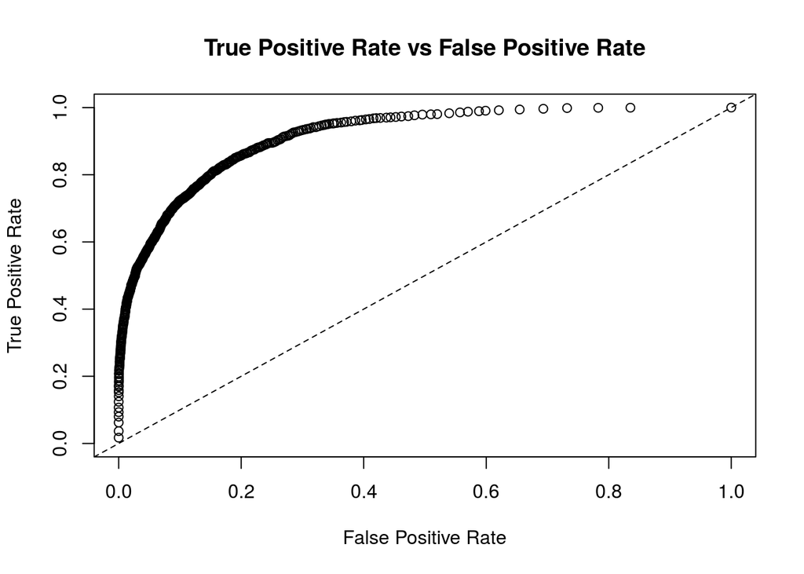

And the test AUC on the test data is given by:

```
## [1] 0.9156978
```

# 3. Final Discussion

## 3.1 Comparison between different algorithms

The plot will be presented about the AUC for different algorithm, and for multiple models with same algorithm, they will be assigned same color.

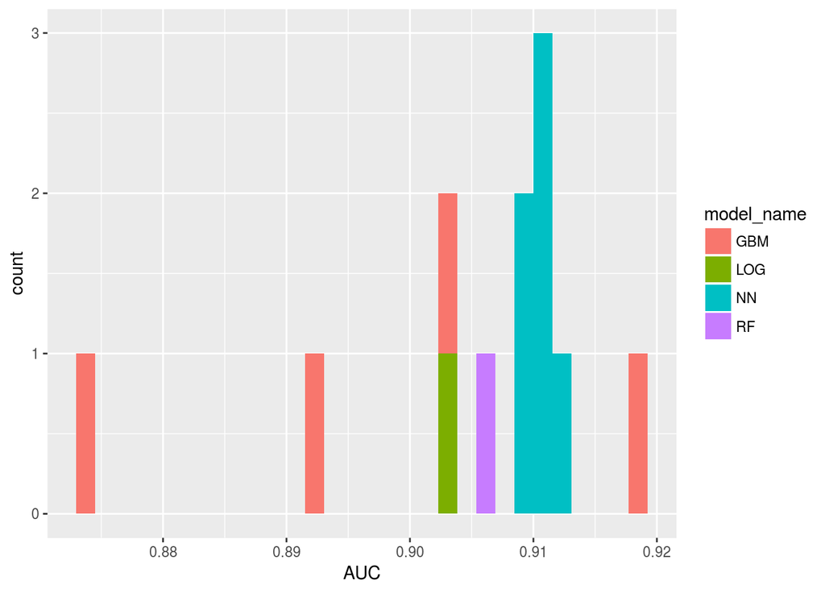

As for those algorithms, the neural network trends to have stable higher AUC, while with hyperparameter random search, GBM takes the first place. This is worth to notice that the hyperparameter optimization is amazing to achieve better model.

However, the AUC range is from 0.87 to 0.92 as the graph above shows. So that AUC doesn’t really change a lot and if it takes 10 times to make a 0.01 progress, we’d better don’t do it.

## 3.2 The cost-benefit analysis(Time vs AUC)

The time vs auc plot is presented for different model, the mixed model is presented as well.

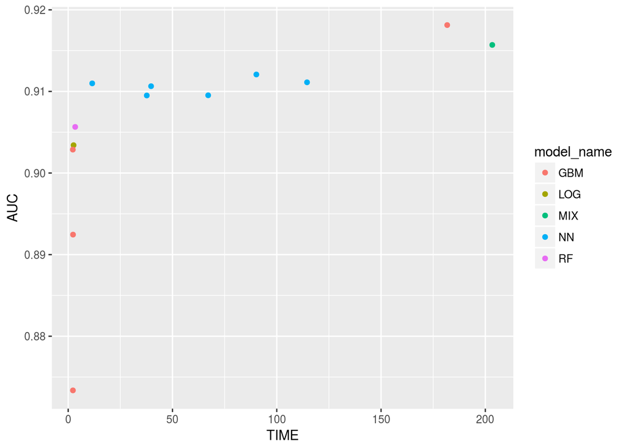

This plot gives a nice idea about the time cost against the auc as a metric of the goodness.

The trend shows that with more time, it’s possible to achieve better AUC on test data set. However, the change is not dramatic, only from 0.91 to 0.92, and this movement takes more than 150 seconds. So we definitely don’t want to do that.

The plot below will show exact name of the model:

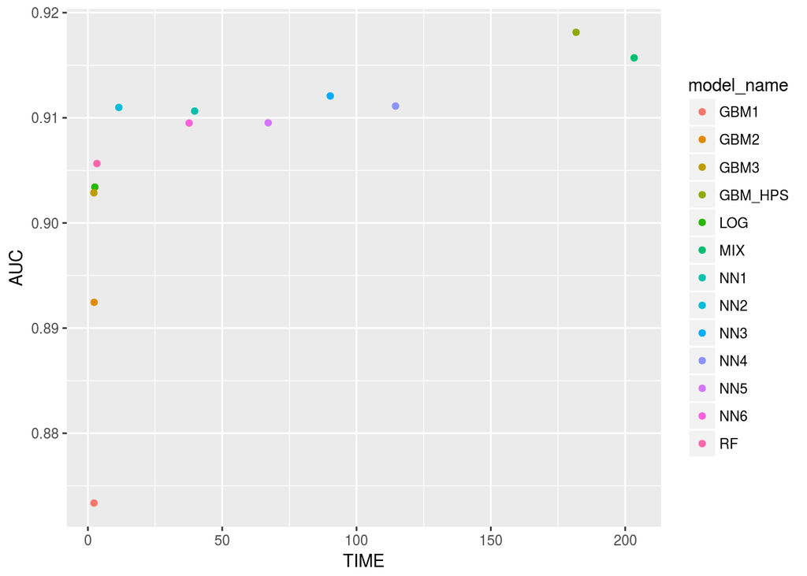

It turns out the No.2 neural network model is the best, with really fast speed:

```
## elapsed
##  11.524
```

And relatively high auc:

```
## [1] 0.9109862
```

And the rank of this auc in all the models is:

```
## [1] 5
```

I really like this model and consider this model as my predictive model for this data. High speed and top 5 auc.

This should be the best one among those.

More inspection can be checked on h2o.flow, as well as picking an optimal cut off point based on different criterias.

The whole project was built on Amazon EC2 with big memory, for the hyperparameter tuning ate up all 8 Gb once, and the 8 cores machine made life easier for my PC, also saved a lot of time.

Further modification comming some, some criteria might be included, such as hyperparameter tuning on neural network models.